# Fantastic Models and How to Find Them

Nate Selleck

10/5/2021

Example 1 - Annual Return of LOWA

$~$

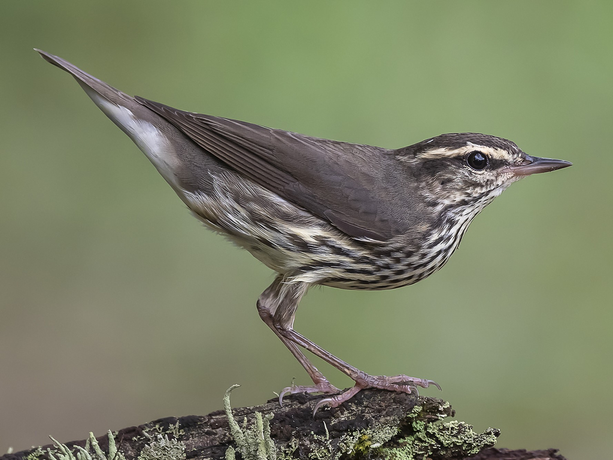

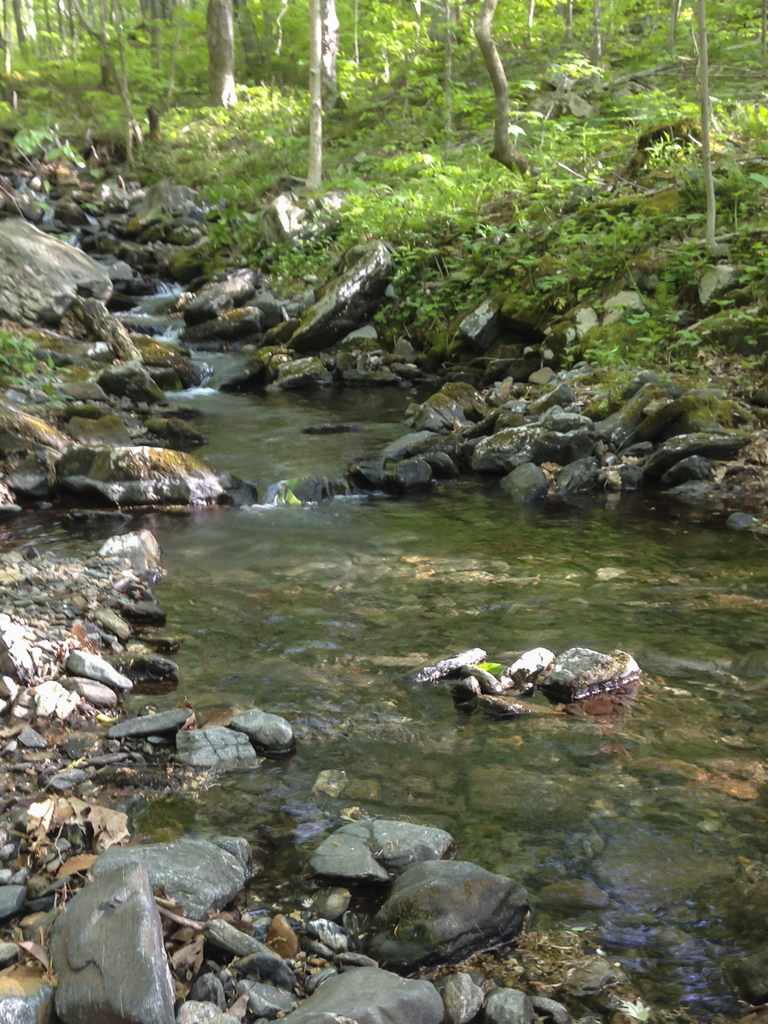

Image 2 - Typical Louisiana Waterthrush habitat.

$~$

First, I imported the data and cleaned it up. I then checked for correlation among the variables.

$~$

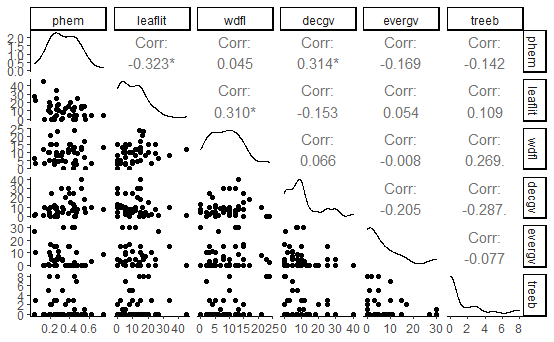

```r
lowa_return <- read.csv("data/lowa_return_data.csv")
lowa_return <- clean_names(lowa_return)
lowa_return <- na.omit(lowa_return)

Veg <- lowa_return[, c("phem", "leaflit", "wdfl", "decgv", "evergv", "treeb")]

ggpairs(Veg) + theme_classic()
```

It seems that the proportion of hemlock at the study site (phem) is correlated with leaf litter and deciduous ground vegetation (decgv). Based on this, I modeled the data and checked for collinearity.

$~$

```r
model_lowa1 <- lm(i_return ~ phem + leaflit + wdfl + decgv + evergv + treeb, data=lowa_return)
anova (model_lowa1)
```

```
Analysis of Variance Table

Response: i_return
          Df Sum Sq Mean Sq F value  Pr(>F)
phem       1 0.0073 0.00726  0.0332 0.85635
leaflit    1 0.5174 0.51744  2.3676 0.13217
wdfl       1 0.0849 0.08493  0.3886 0.53675
decgv      1 0.6718 0.67181  3.0739 0.08762 .
evergv     1 0.0000 0.00003  0.0001 0.99122
treeb      1 1.2134 1.21345  5.5521 0.02372 *
Residuals 38 8.3051 0.21855
---
Signif. codes:  0 ‘***’ 0.001 ‘**’ 0.01 ‘*’ 0.05 ‘.’ 0.1 ‘ ’ 1
```

```r
performance::check_collinearity(model_lowa1)
```

```
# Check for Multicollinearity

Low Correlation

    Term  VIF Increased SE Tolerance
    phem 1.26         1.12      0.79
 leaflit 1.28         1.13      0.78
    wdfl 1.26         1.12      0.79
   decgv 1.27         1.13      0.78
  evergv 1.09         1.04      0.92
   treeb 1.24         1.11      0.81
```

$~$ Thankfully, all of the variables seem to have low correlation.

```r
options(na.action = "na.fail") # otherwise blows up with NA values
dredge_lowa<-dredge(model_lowa1)
```

```
Fixed term is "(Intercept)"
```

```r
dredge_lowa
```

```
Global model call: lm(formula = i_return ~ phem + leaflit + wdfl + decgv + evergv +
    treeb, data = lowa_return)
---
Model selection table
   (Intrc)   decgv      evrgv     leflt     phem   treeb
18  0.3069 0.01856                               0.06976
22  0.4315 0.01718            -0.010210          0.07273
50  0.3753 0.01951                               0.07731
30  0.5630 0.01871            -0.011810 -0.37180 0.07188
20  0.2747 0.01930  3.265e-03                    0.07150
26  0.3492 0.01923                      -0.14040 0.06926
24  0.3967 0.01799  3.671e-03 -0.010320          0.07472
54  0.4535 0.01775            -0.009345          0.07607
2   0.4588 0.01352
21  0.6604                    -0.012270          0.05411
```

[output cut: 120 more lines]

$~$ Because of the large(ish) amount of models, I decided to subset all models with a delta AIC less than 5. When that still returned a fair amount, I subsetted all of those with a delta AIC less than 2.

$~$

```r
subset(dredge_lowa, delta <5)
```

```
Global model call: lm(formula = i_return ~ phem + leaflit + wdfl + decgv + evergv +
    treeb, data = lowa_return)
---
Model selection table
   (Intrc)   decgv    evrgv     leflt    phem   treeb      wdfl
18  0.3069 0.01856                            0.06976
22  0.4315 0.01718          -0.010210         0.07273
50  0.3753 0.01951                            0.07731 -0.009822
30  0.5630 0.01871          -0.011810 -0.3718 0.07188
20  0.2747 0.01930 0.003265                   0.07150
26  0.3492 0.01923                    -0.1404 0.06926
24  0.3967 0.01799 0.003671 -0.010320         0.07472
54  0.4535 0.01775          -0.009345         0.07607 -0.004673
2   0.4588 0.01352
21  0.6604                  -0.012270         0.05411
```

[output cut: 26 more lines]

```r
subset(dredge_lowa, delta<2)
```

```
Global model call: lm(formula = i_return ~ phem + leaflit + wdfl + decgv + evergv +
    treeb, data = lowa_return)
---
Model selection table
   (Intrc)   decgv    leflt   treeb      wdfl df  logLik AICc
18  0.3069 0.01856          0.06976            4 -27.388 63.8
22  0.4315 0.01718 -0.01021 0.07273            5 -26.261 64.1
50  0.3753 0.01951          0.07731 -0.009822  5 -27.044 65.6
   delta weight
18  0.00  0.442
22  0.28  0.383
50  1.85  0.175
Models ranked by AICc(x)
```

```r
importance(dredge_lowa)
```

```
                     decgv treeb leaflit wdfl phem evergv
Sum of weights:      0.78  0.78  0.46    0.24 0.24 0.23
N containing models:   32    32    32      32   32   32
```

$~$ Only three models had a delta AIC less than 2. The two most important variables were the percentage of deciduous ground vegetation and the percentage of live tree boles. Both appeared in 32 of the 64 models.

```r
model.avg(dredge_lowa, revised.var = TRUE)
```

```
Call:
model.avg(object = dredge_lowa, revised.var = TRUE)

Component models:
‘15’     ‘135’    ‘156’    ‘1345’   ‘125’    ‘145’    ‘1235’
‘1356’   ‘1’      ‘35’     ‘5’      ‘13’     ‘(Null)’ ‘3’
‘1256’   ‘1456’   ‘1245’   ‘12345’  ‘13456’  ‘14’     ‘12356’
‘16’     ‘12’     ‘345’    ‘356’    ‘235’    ‘134’    ‘45’
‘56’     ‘25’     ‘2’      ‘4’      ‘36’     ‘6’      ‘136’
‘34’     ‘123’    ‘23’     ‘12456’  ‘146’    ‘124’    ‘123456’
‘126’    ‘1346’   ‘456’    ‘3456’   ‘2345’   ‘2356’   ‘256’
‘245’    ‘1234’   ‘24’     ‘26’     ‘346’    ‘46’     ‘236’
‘234’    ‘1236’   ‘1246’   ‘2456’   ‘12346’  ‘246’    ‘23456’
‘2346’

Coefficients:
       (Intercept)      decgv      treeb     leaflit        wdfl
full      0.456607 0.01389891 0.05450763 -0.00494223 -0.00118506
subset    0.456607 0.01772469 0.06955344 -0.01074540 -0.00487408
             phem       evergv
full   -0.0467789 0.0004390817
subset -0.1969235 0.0019496450
```

```r
summary(model.avg(dredge_lowa, subset = delta <2 ))
```

```
Call:
model.avg(object = dredge_lowa, subset = delta < 2)

Component model call:
lm(formula = i_return ~ <3 unique rhs>, data =
     lowa_return)

Component models:
    df logLik  AICc delta weight
13   4 -27.39 63.78  0.00   0.44
123  5 -26.26 64.06  0.28   0.38
134  5 -27.04 65.63  1.85   0.18

Term codes:
  decgv leaflit   treeb    wdfl
      1       2       3       4

Model-averaged coefficients:
(full average)
             Estimate Std. Error Adjusted SE z value Pr(>|z|)
(Intercept)  0.366637   0.147720    0.151527   2.420   0.0155 *
decgv        0.018199   0.007592    0.007817   2.328   0.0199 *
treeb        0.072219   0.030148    0.031047   2.326   0.0200 *
leaflit     -0.003913   0.006604    0.006692   0.585   0.5588
wdfl        -0.001721   0.006374    0.006502   0.265   0.7912

(conditional average)
             Estimate Std. Error Adjusted SE z value Pr(>|z|)
(Intercept)  0.366637   0.147720    0.151527   2.420   0.0155 *
decgv        0.018199   0.007592    0.007817   2.328   0.0199 *
treeb        0.072219   0.030148    0.031047   2.326   0.0200 *
leaflit     -0.010211   0.007036    0.007249   1.409   0.1590
wdfl        -0.009822   0.012341    0.012716   0.772   0.4399
---
Signif. codes:  0 ‘***’ 0.001 ‘**’ 0.01 ‘*’ 0.05 ‘.’ 0.1 ‘ ’ 1
```

$~$ The summary just further reinforces that deciduous ground vegetation and live tree boles are the two most important variables, with both having significant effects on whether birds return to the previous season’s nesting site.

$~$

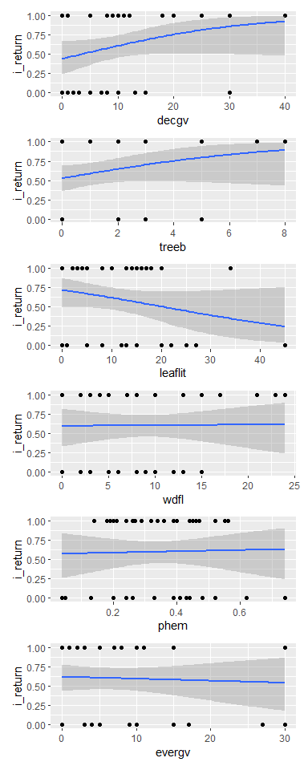

```r
l1 <- ggplot(lowa_return, aes(decgv, i_return)) +
  geom_point() +
  geom_smooth(method="glm", method.args=list(family="binomial"(link="logit")))

l2 <- ggplot(lowa_return, aes(treeb, i_return)) +
  geom_point() +
  geom_smooth(method="glm", method.args=list(family="binomial"(link="logit")))

l3 <- ggplot(lowa_return, aes(leaflit, i_return)) +
  geom_point() +
  geom_smooth(method="glm", method.args=list(family="binomial"(link="logit")))

l4 <- ggplot(lowa_return, aes(wdfl, i_return)) +
  geom_point() +
  geom_smooth(method="glm", method.args=list(family="binomial"(link="logit")))

l5 <- ggplot(lowa_return, aes(phem, i_return)) +
  geom_point() +
  geom_smooth(method="glm", method.args=list(family="binomial"(link="logit")))

l6 <- ggplot(lowa_return, aes(evergv, i_return)) +
  geom_point() +
  geom_smooth(method="glm", method.args=list(family="binomial"(link="logit")))

l1 / l2 / l3 / l4 / l5 / l6
```

Example 2 - Nest Survival $~$

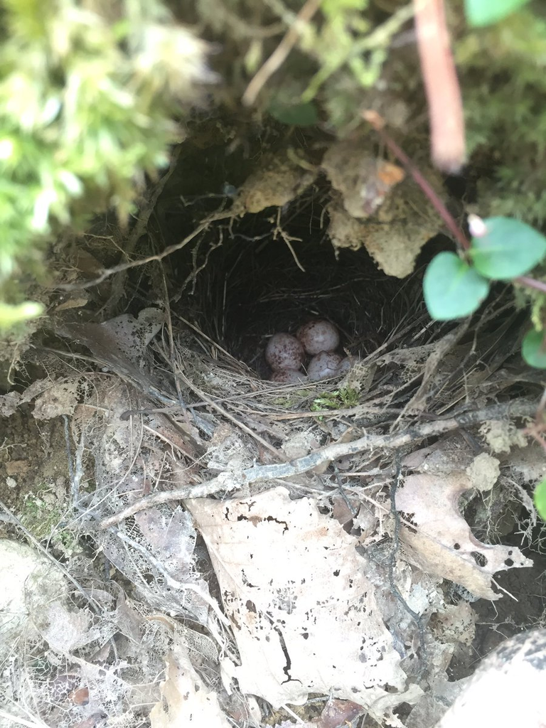

Image 3 - A Louisiana Waterthrush nest

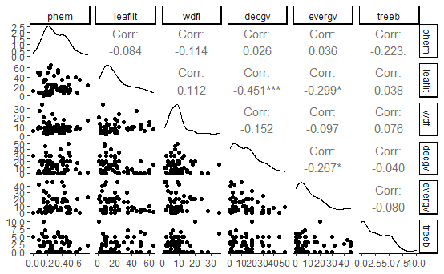

```r
lowa_survival <- read.csv("data/lowa_nest_survival.csv")
lowa_survival <- clean_names(lowa_survival)
lowa_survival <- na.omit(lowa_survival)

surv <- lowa_survival[, c("phem", "leaflit", "wdfl", "decgv", "evergv", "treeb")]

ggpairs(surv) + theme_classic()
```

```r
model_lowa2 <- lm(f ~ phem + leaflit + wdfl + decgv + evergv + treeb, data=lowa_survival)
anova (model_lowa2)
```

```
Analysis of Variance Table

Response: f
          Df  Sum Sq Mean Sq F value  Pr(>F)
phem       1  0.1482 0.14817  0.5756 0.45113
leaflit    1  0.8782 0.87824  3.4115 0.06985 .
wdfl       1  0.0444 0.04439  0.1724 0.67949
decgv      1  0.1955 0.19549  0.7594 0.38712
evergv     1  0.0060 0.00597  0.0232 0.87947
treeb      1  0.0118 0.01178  0.0458 0.83134
Residuals 58 14.9313 0.25744
---
Signif. codes:  0 ‘***’ 0.001 ‘**’ 0.01 ‘*’ 0.05 ‘.’ 0.1 ‘ ’ 1
```

```r
performance::check_collinearity(model_lowa2)
```

```
# Check for Multicollinearity

Low Correlation

    Term  VIF Increased SE Tolerance
    phem 1.07         1.03      0.94
 leaflit 1.66         1.29      0.60
    wdfl 1.06         1.03      0.94
   decgv 1.67         1.29      0.60
  evergv 1.45         1.20      0.69
   treeb 1.06         1.03      0.94
```

```r
options(na.action = "na.fail") # otherwise blows up with NA values
dredge_lowa2 <- dredge(model_lowa2)
```

```
Fixed term is "(Intercept)"
```

```r
dredge_lowa2
```

```
Global model call: lm(formula = f ~ phem + leaflit + wdfl + decgv + evergv + treeb,
    data = lowa_survival)
---
Model selection table
   (Intrc)    decgv      evrgv     leflt   phem     treeb
5   0.6346                     -0.007278
2   0.3551 0.008549
6   0.5226 0.005204            -0.005530
1   0.4769
13  0.5543                     -0.007084 0.2441
37  0.6770                     -0.007072
21  0.6577                     -0.007220        -0.010490
7   0.6577          -0.0013600 -0.007580
4   0.2872 0.009689  0.0042640
10  0.2660 0.008455                      0.2898
```

[output cut: 120 more lines]

```r
subset(dredge_lowa2, delta<2)
```

```
Global model call: lm(formula = f ~ phem + leaflit + wdfl + decgv + evergv + treeb,
    data = lowa_survival)
---
Model selection table
   (Intrc)    decgv     leflt   phem df  logLik AICc delta weight
5   0.6346          -0.007278         3 -45.181 96.8  0.00  0.337
2   0.3551 0.008549                   3 -45.642 97.7  0.92  0.213
6   0.5226 0.005204 -0.005530         4 -44.728 98.1  1.37  0.170
1   0.4769                            2 -47.107 98.4  1.65  0.148
13  0.5543          -0.007084 0.2441  4 -44.982 98.6  1.88  0.132
Models ranked by AICc(x)
```

```r
importance(dredge_lowa2)
```

```
                     leaflit decgv phem wdfl evergv treeb
Sum of weights:      0.56    0.44  0.28 0.26 0.26   0.25
N containing models:   32      32    32   32   32     32
```

```r
model.avg(dredge_lowa2, revised.var = TRUE)
```

```
Call:
model.avg(object = dredge_lowa2, revised.var = TRUE)

Component models:
‘3’      ‘1’      ‘13’     ‘(Null)’ ‘34’     ‘36’     ‘35’
‘23’     ‘12’     ‘14’     ‘16’     ‘15’     ‘4’      ‘134’
‘6’      ‘136’    ‘135’    ‘5’      ‘123’    ‘2’      ‘346’
‘345’    ‘234’    ‘356’    ‘236’    ‘124’    ‘235’    ‘126’
‘125’    ‘146’    ‘145’    ‘46’     ‘156’    ‘45’     ‘24’
‘56’     ‘26’     ‘1346’   ‘1345’   ‘1234’   ‘25’     ‘1356’
‘1235’   ‘1236’   ‘2346’   ‘3456’   ‘2345’   ‘2356’   ‘1246’
‘1245’   ‘1256’   ‘1456’   ‘456’    ‘246’    ‘245’    ‘256’
‘13456’  ‘12346’  ‘12345’  ‘12356’  ‘23456’  ‘12456’  ‘2456’
‘123456’

Coefficients:
       (Intercept)      leaflit       decgv       phem
full     0.5018164 -0.003686937 0.003234430 0.07201885
subset   0.5018164 -0.006630070 0.007341124 0.25798577
               wdfl        treeb       evergv
full   -0.001265213 -0.002379054 0.0003063556
subset -0.004877314 -0.009506670 0.0011834256
```

```r
summary(model.avg(dredge_lowa2, subset = delta <2 ))
```

```
Call:
model.avg(object = dredge_lowa2, subset = delta < 2)

Component model call:
lm(formula = f ~ <5 unique rhs>, data = lowa_survival)

Component models:
       df logLik  AICc delta weight
2       3 -45.18 96.75  0.00   0.34
1       3 -45.64 97.68  0.92   0.21
12      4 -44.73 98.12  1.37   0.17
(Null)  2 -47.11 98.41  1.65   0.15
23      4 -44.98 98.63  1.88   0.13

Term codes:
  decgv leaflit    phem
      1       2       3

Model-averaged coefficients:
(full average)
             Estimate Std. Error Adjusted SE z value Pr(>|z|)
(Intercept)  0.522189   0.156061    0.157803   3.309 0.000936 ***
leaflit     -0.004332   0.004514    0.004555   0.951 0.341618
decgv        0.002705   0.004848    0.004892   0.553 0.580339
phem         0.032239   0.165963    0.168453   0.191 0.848225

(conditional average)
             Estimate Std. Error Adjusted SE z value Pr(>|z|)
(Intercept)  0.522189   0.156061    0.157803   3.309 0.000936 ***
leaflit     -0.006773   0.003914    0.003989   1.698 0.089521 .
decgv        0.007063   0.005531    0.005631   1.254 0.209728
phem         0.244129   0.396036    0.403918   0.604 0.545576
---
Signif. codes:  0 ‘***’ 0.001 ‘**’ 0.01 ‘*’ 0.05 ‘.’ 0.1 ‘ ’ 1
```

```r
l7 <- ggplot(lowa_survival, aes(decgv, f)) +
  geom_point() +
  geom_smooth(method="glm", method.args=list(family="binomial"(link="logit")))

l8 <- ggplot(lowa_survival, aes(treeb, f)) +
  geom_point() +
  geom_smooth(method="glm", method.args=list(family="binomial"(link="logit")))

l9 <- ggplot(lowa_survival, aes(leaflit, f)) +
  geom_point() +
  geom_smooth(method="glm", method.args=list(family="binomial"(link="logit")))

l10 <- ggplot(lowa_survival, aes(wdfl, f)) +
  geom_point() +
  geom_smooth(method="glm", method.args=list(family="binomial"(link="logit")))

l11 <- ggplot(lowa_survival, aes(phem, f)) +
  geom_point() +
  geom_smooth(method="glm", method.args=list(family="binomial"(link="logit")))

l12 <- ggplot(lowa_survival, aes(evergv, f)) +
  geom_point() +
  geom_smooth(method="glm", method.args=list(family="binomial"(link="logit")))

l7 / l8 / l9 / l10 / l11 / l12
```

[output not shown]